# PADP8120_Homework2

J. Parisi

```r
library(dplyr)
```

# Homework 2

Guidelines: Homeworks should be clear and legible, with answers clearly indicated and work shown. Homeworks will be given a minus, check, or check plus owing to completion and correctness. You are welcome to work with others but please submit your own work. Your homework must be produced in an R Markdown (.rmd) file submitted via github. If you are having trouble accomplishing this, please refer to the [guide](http://spia.uga.edu/faculty_pages/tyler.scott/teaching/PADP8120_Fall2015/Homeworks/submitting_homework.shtml). This homework adapts materials from the work of Michael Lynch (http://spia.uga.edu/faculty_pages/mlynch/), Tyler McCormick (http://www.stat.washington.edu/~tylermc/), and Open Intro (https://www.openintro.org/stat/textbook.php)

## Topics

Topics covered in this homework include:

- Probability
- Random Variables
- Inference and hypotheses

## Problems

1. Being hit by a chair is a common occurrence in WWE professional wrestling. The number of people hit upside the head with chairs can vary from program to program. Suppose that the number of chair-bashings per program is Normally distributed, with mean thirty-five (35) bashings and standard deviation of eight (8) bashings. What is the probability that one WWE program will contain less than nineteen (19) bashings or more than forty (40) bashings?

The probability that a WWE program will contain less than 19 bashings or more than 40 bashings is 0.289.

2. A corporation has just received new machinery that must be installed and checked before it becomes operational. The following table shows a manager’s probability assessment for the number of days required before the machinery becomes operational:

| Days | 5 | 6 | 7 | 8 | 9 | 10 |
| --- | --- | --- | --- | --- | --- | --- |
| Prob. | 0.06 | 0.21 | 0.37 | 0.20 | 0.13 | 0.03 |

Let A be the event that it will be more than 6 days before the machinery becomes operational, and let B be the event that it will be less than 8 days before the machinery becomes available.

1. Find the probability of event A.
2. Find the probability of event B.
3. Find the probability of the complement of event A.
4. Find the probability of the intersection of events A and B.
5. Find the probability of the union of events A and B.

```r
q2<-rep(NA, 5)
days<-5:10
prob<-c(0.06, 0.21, 0.37, 0.20, 0.13, 0.03)
q2[1]<-sum(prob[3:6])
q2[2]<-sum(prob[1:3])
q2[3]<-(1-q2[1])
q2[4]<-0.37
q2[5]<-q2[1]+q2[2]-q2[4]
```

The answers to the 5 subquestions of Question 2 are as follows:

```r
print(q2)
```

```
## [1] 0.73 0.64 0.27 0.37 1.00
```

3. An ultramarathon race official has found that 68% of first time entrants and 87% of repeat racers finish the race. Of all entrants, 64% are repeat racers and the remainders are first time entrants.
1. What is the probability that a randomly chosen entrant is a repeat racer who will eventually finish the race?
2. Find the probability that a randomly chosen entrant will eventually finish the race.
3. What is the probability that a randomly chosen entrant either is a repeat racer or will eventually finish (or both)?
- The probability P(repeat racer AND will finish race) is 0.64x0.87 = 0.56.
- The probability for 3b is .68x.36 + .87x.64 = 0.8.
- This is P(repeat racer OR will finish race) - P(repeat racer AND will finish race), which is 0.64 + 0.8 - 0.64x0.87 = 0.88.
4. A school received a grant to offer two extracurricular clubs, art and chess. Of the students 35% signed up for art club and 40% for chess club. Of those signing up for art club 20% signed up for chess club.
1. What is the probability that a randomly selected student signed up for both clubs?

The probability is 0.07.

2. What is the probability that a randomly selected sutdent who signed up for chess club also signed up for art club?

The probability is 0.18.

3. What is the probability that a randomly chosen student signed up for at least one of these two clubs?

5. Records show that 442 students recently entered a Florida public school district. Of those 442, 84 have not received their vaccinations. The district’s physician is scheduled to go from school to school next Tuesday to give shots to those who need them. If we know that about 8% of students are absent on any given day, how many unvaccinated students are likely to miss the doctor visit?

The probability of being unvaccinated is 0.19. Since all students are equally likely to be absent, the answer is 6.72.

6. For questions 1a - 1c, assume a variable is normally distributed with a mean of 180 and a standard deviation of 25. Please show all work (i.e., relevant code - hint: the `pnorm`/`qnorm`/`dnorm` family will be your friend here)
1. What is the probability that a single draw from this distribution, labeled X, will be greater than 210?

The probability is:

```r
x<-pnorm(210, mean=180, sd=25, lower.tail=FALSE)
round(x,2)
```

```
## [1] 0.12
```

2. What is the probability that a single draw from this distribution, labeled Y, will be less than 182?

The probability is:

```r
y<-pnorm(182, mean=180, sd=25, lower.tail=TRUE)
round(y,2)
```

```
## [1] 0.53
```

3. What is the probability that a single draw from this distribution, labeled Z, will be between 160 and 192?

The probability is:

```r
z<-(pnorm(192, mean=180, sd=25) - pnorm(160, mean=180, sd=25))
round(z,2)
```

```
## [1] 0.47
```

```r
print("Answer key wrong on this one? Or am I?")
```

```
## [1] "Answer key wrong on this one? Or am I?"
```

7. The random variable x has the discrete probability distribution shown here:

| x | -2 | -1 | 0 | 1 | 2 |
| --- | --- | --- | --- | --- | --- |
| p(x) | 0.15 | 0.15 | 0.35 | 0.25 | 0.10 |

1. Find $P(x<=0)$ The probability is 0.65.
2. Find $P(x>-1)$ The probability is 0.7.
3. Find $P(-1<=x<=1)$ The probability is 0.75.
4. Find $P(x<2)$ The probability is 0.9.
5. Find $P(-1<x<2)$ The probability is 0.6.

I realize I did not need to round any of the above answers…

8. Skipped
9. Consider flipping an unequally weighted coin with probability of success $.55$. Say that $X$ is the random variable associated with this coin and that $X=1$ if heads (success), 0 otherwise. Simulate 20 coin flips and store them as a variable called “cflip.” In R, do this with `cflip=rbinom(20,1,.55)`. Use `?rbinom` to make sure you understand what each part of the command stands for.
1. Take 20 samples with replacement from cflip and compute the mean of the sample. In R: `cflipsamp=sample(cflip,20,replace=T)`

```r
cflip=rbinom(20,1,0.55)

#After testing the 'size' parameter, I see that rbinom returns the number of successes for each observation.

cflipsamp=sample(cflip,20,replace=T)
mean(cflipsamp)
```

```
## [1] 0.6
```

2. Repeat step B (but not step A) 500 times, storing the mean of the sample each time. You could do this using a “for” loop to repeat the same step many times. An example of code for a loop is below. However, try to find a non-loop way of accomplishing the same thing (e.g., the `replicate` function). `resamp.mean=rep(NA,500) for(i in 1:500){ resamp.mean[i]<-mean(sample(cflip,20,replace=T))}`.

```r
resamp.mean<-replicate(500, mean(sample(cflip,20,replace=T)))
```

3. Plot a histogram of the re-sampled means. Does it look like what we know from normal theory that the sampling distribution of the mean should look like in this case?

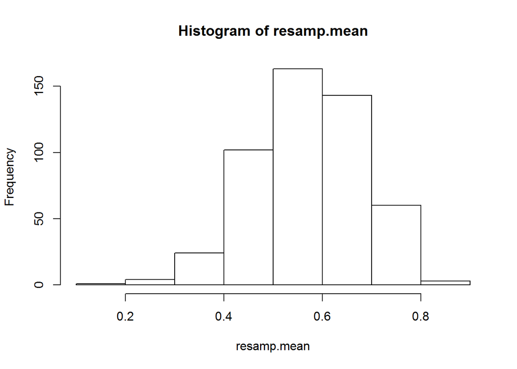

```r
hist(resamp.mean)
```

4. Experiment with increasing/decreasing the number of original samples (draws within one “sample”) and the number of re-samples (number of times you repeat the sampling process). Pay attention to the impact changing either has on the resulting distribution of sample means, and provide some form of visual demonstration (table and/or figure) to show how sample size changes your results.

`resamp.mean=rep(NA,500) for(i in 1:500){ resamp.mean[i]<-mean(sample(cflip,20,replace=T))}`.

cflip=rbinom(20,1,0.55)

```r
mean(cflip)
```

```
## [1] 0.6
```

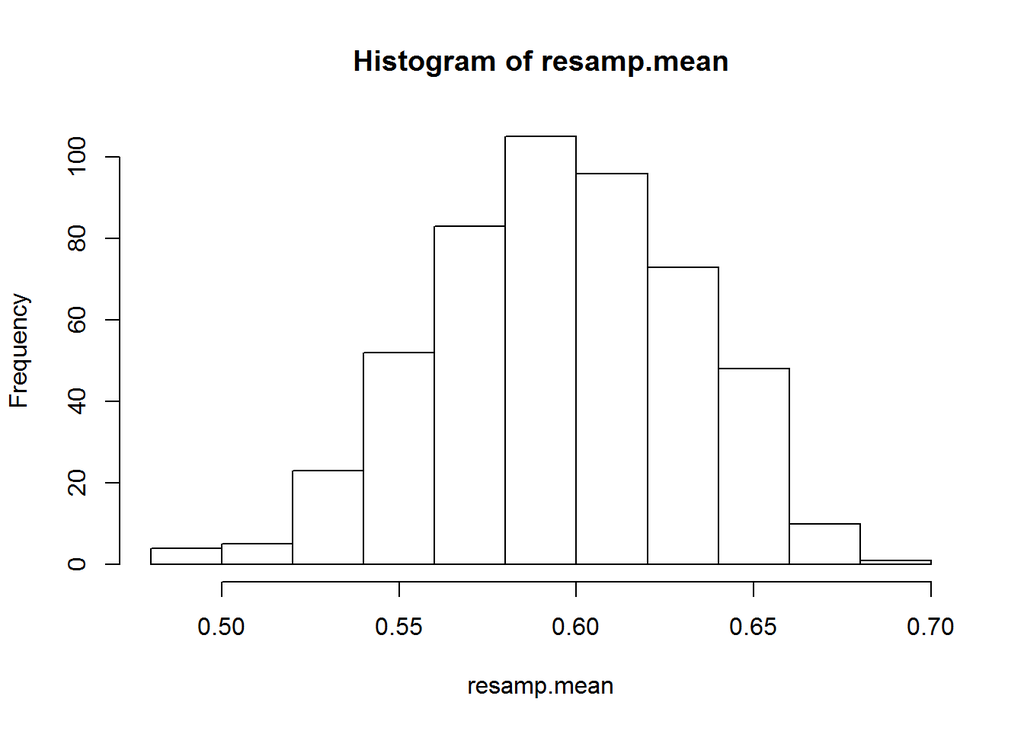

```r
resamp.mean<-replicate(500, mean(sample(cflip,200,replace=T)))

hist(resamp.mean)
```

Increasing the draws in each sample appears to get the histogram looking more consistently in line with the mean of the cflip variable.

```r
mean(cflip)
```

```
## [1] 0.6
```

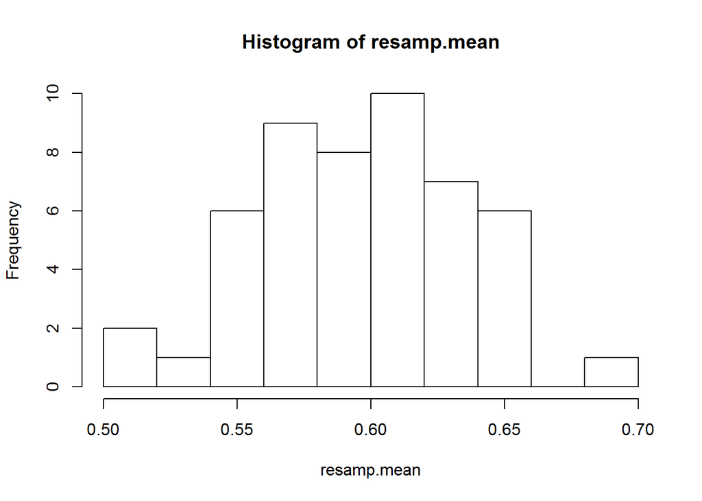

```r
#cflipsamp=sample(cflip,200,replace=T)

resamp.mean<-replicate(50, mean(sample(cflip,200,replace=T)))

hist(resamp.mean)
```

Lowering the number of replications in the sample process results in a less normal looking distribution, although the heaviest concentration still seems to be about the mean of the cflip variable.

```r
cflip=rbinom(500,1,0.55)
mean(cflip)
```

```
## [1] 0.546
```

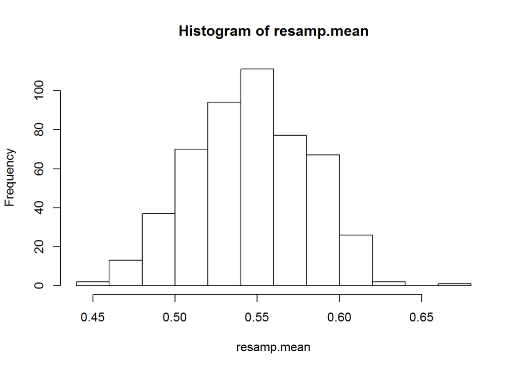

```r
#cflipsamp=sample(cflip,200,replace=T)

resamp.mean<-replicate(500, mean(sample(cflip,200,replace=T)))

hist(resamp.mean)
```

Increasing the number of observations in the original rbinom generation gets us closer to what we would expect to see with our unfair coin.

10. Consider a population of donuts with with an average survival time until becoming stale of $\mu = 3$ days and is exponentially distributed (so the mean = sd). If you take a sample of 24 donuts, what are the chances the mean failure time of your sample will be:

PLEASE SKIP THIS PROBLEM

1. Greater than 3 days?

```r
pexp(3,rate = 1/3,lower.tail=FALSE)
```

```
## [1] 0.3678794
```

This seems weird that pexp is testing the *mean* failure time (per answer key), while pnorm is giving us the probability of a single given obervation falling in a region…

2. Less than 1.5 days?

```r
pexp(1.5,rate = 1/3,lower.tail=TRUE)
```

```
## [1] 0.3934693
```

3. Between 2.25 and 3.75 days?

```r
pexp(3.75,rate = 1/3,lower.tail=TRUE) - pexp(2.25,rate = 1/3,lower.tail=TRUE)
```

```
## [1] 0.1858618
```

11. (also problem 4.17/4.18 in Open Intro 3) Identify hypotheses, For each item, write the null and alternative hypotheses in words and then symbols for each of the following situations.
1. New York is known as city that never sleeps“. A random sample of 25 New Yorkers wereasked how much sleep they get per night. Do these data provide convincing evidence that New Yorkers on average sleep less than 8 hours a night?

Null: Mean hours >= 8 Alt: Mean hours < 8

2. Employers at a firm are worried about the effect of March Madness, a basketball championship held each spring in the US, on employee productivity. They estimate that on a regular businessday employees spend on average 15 minutes of company time checking personal email, making personal phone calls, etc. They also collect data on how much company time employees spend on such non-business activities during March Madness. They want to determine if these data provide convincing evidence that employee productivity decreases during March Madness.

Null: Avg hours non-business (MM) - Avg hours non-business (Normal) <=0 Alt: Avg hours non-business (MM) - Avg hours non-business (Normal) >0

3. Since 2008, chain restaurants in California have been required to display calorie counts ofeach menu item. Prior to menus displaying calorie counts, the average calorie intake of dinersat a restaurant was 1100 calories. After calorie counts started to be displayed on menus,a nutritionist collected data on the number of calories consumed at this restaurant from arandom sample of diners. Do these data provide convincing evidence of a difference in theaverage calorie intake of a diners at this restaurant?

Null: Avg calories (Post Chg) - Avg Calories (Pre-Chg) = 0 Alt: Avg calories (Post Chg) - Avg Calories (Pre-Chg) != 0

4. Based on the performance of those who took the GRE exam between July 1, 2004 and June 30, 2007, the average Verbal Reasoning score was calculated to be 462. In 2011 the averageverbal score was slightly higher. Do these data provide convincing evidence that the average GRE Verbal Reasoning score has changed since 2004?

Null: 2011 Avg Verbal Score = 462 Alt: 2011 Avg Verbal Score != 462

12. (also 4.30 in Open Intro 3) A food safety inspector is called upon to investigate a restau-rant with a few customer reports of poor sanitation practices. The food safety inspector uses ahypothesis testing framework to evaluate whether regulations are not being met. If he decides therestaurant is in gross violation, its license to serve food will be revoked.
1. Write the hypotheses in words.

Null: The restaurant is not in gross violation. Alt: The restaurant is in gross violation.

2. What is a Type 1 Error in this context?

This would be revoking the restaurant’s food license when it actually was not in gross violation.

3. What is a Type 2 Error in this context?

This would be failing to revoke the license even though the restaurant is in gross violation.

4. Which error is more problematic for the restaurant owner? Why?

Clearly the Type 1 Error would be more problematic, as it is the only one that involves losing its license.

5. Which error is more problematic for the diners? Why?’

Type 2 error would be more problematic, as the food may be unsanitary. Although it depends how much people like the food (ha, ha, ha).

### Report your process

You’re encouraged to reflect on what was hard/easy, problems you solved, helpful tutorials you read, etc. Give credit to your sources, whether it’s a blog post, a fellow student, an online tutorial, etc.

### Rubric

Minus: Didn’t tackle at least 3 tasks. Or didn’t make companion graphs. Didn’t interpret anything but left it all to the “reader”. Or more than one technical problem that is relatively easy to fix. It’s hard to find the report in our repo.

Check: Completed, but not fully accurate and/or readable. Requires a bit of detective work on my part to see what you did

Check plus: Hits all the elements. No obvious mistakes. Pleasant to read. No heroic detective work required. Solid.

#### The command below is helpful for debugging, please don’t change it

[output not shown]